# Topic 17

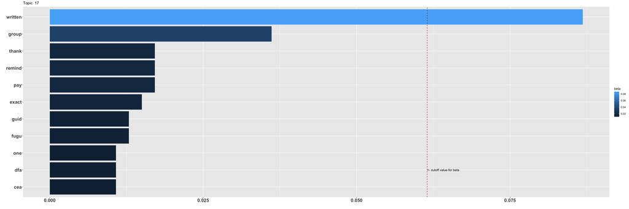

On interpreting beta: the term has a beta probability of being generated from the particular topic.

Values below are gamma : An estimated proportion of words from that document that are generated from that topic.

**Text Record Number: 573** gamma: 24 % likelihood of this document (based on its words) in this topic

**As Paul said (or at least that’s what she calls him) “changing some to easier inversions will help your hand position/movement.”

Bingo! Bingo! Bingo! Totally take the time to learn inversions!

1. Try your progression this way, and see how much freer things become (same chords, but notes in different order, call “inversions”):

DF#A, DGB, C#EA, BDF# DGB, DF#A, C#EA, DF#A

DGB, C#EA, DF#B DGB, C#EA, DF#A

2. Just play your root note in the LH as you are doing, and if you want the “tight, sing along” sound, bring it only an octave below the RH.**

**Text Record Number: 576** gamma: 24 % likelihood of this document (based on its words) in this topic

**Think I get what you’re asking. If you look closely, they DID write out to play four notes total on the Cm chord, with an Eb in the bass. It’s the exact same Eb you just played for the previous Dm chord.

Notice the duration of the bass notes? They are dotted halves, twice as long as the dotted quarters in the RH. So (starting from the beginning), you play lh D with rh DFA, and then change only the rh to FAD. Then lh Eb with rh DFA, and change only the rh to CEbG. Etc.

So the rhythm in the lh is Note, hold, Note, hold while the rh is Chord, change, change, change.

One thought, from a newbie on piano who knows music and theory? WHEN IN DOUBT the written notes are your key (no pun intended). The answer to your question is right there in the notes, just play them, as written.

All the written out chord names are a very useful tool, but they are guide, and can be subject to different interpretations. I’ve seen sheet music with something like G7(b5) or another odd chord, while there’s only 2 notes actually written out. The written out notes are what’s actually wanted if one reads music, the chords are there as a guide for those who don’t, and it’s basically saying “play G7(b5) and I don’t care how you what notes or inversion you use, as long as it’s a G7(b5).”

Repeating above in a different way. Classical pieces and actual written notes are to be played exactly as the notes are written. The moment someone adds a chord name, that chord name is just a guide, play the chord, however you wish. DO NOT expect the chord names to exactly match the written notes.**

**Text Record Number: 650** gamma: 24 % likelihood of this document (based on its words) in this topic

**For tricky passages, I use the following method which might need to be modified depending on what’s happening rhythmically in the piece you’re trying to learn.

Let’s say they’re groups of 16th notes. For every group of 4 16th notes, select one to lengthen (i.e. play it like an eighth or a quarter note). So to start, make every 1st note in the group a quarter, and play the remaining notes until the 1st note of the next group a tempo or as fast as you can. Do this for the entire passage, or if it’s more than a couple of measures, break it up into pieces.

Next you’ll choose another note to lengthen. You can go in order or randomly. Let’s say the second note of the grouping. So you’ll play the second note of each group of 4 as an eighth or a quarter note and play all other notes a tempo or as fast as you can.

Let me know if you have any questions. I’m not the best at explaining things at 4am lol.**

**Text Record Number: 570** gamma: 24 % likelihood of this document (based on its words) in this topic

**They are a crutch that you will inevitably grow out of, and they can also reinforce some bad habits. The point of learning what all the keys are is so you *don’t* have to think about which key is which. Relying on stickers won’t reinforce that. Instead of looking at a blank key and thinking “which one is this? Oh yeah, it’s F”, you’ll just see a sticker that says “F”, there is no memory recall required. The brain remembers thing best when you have *just* started to forget whatever that information is, when you reintroduce that memory you’re basically telling your brain “hey, this is important information, remember it.” When you’re relying on stickers, this activity is much slower to develop, because you’ll have a constant reminder telling you which ones are which.

If you think about it there’s really only 12 notes you need to learn the positions of on a piano. 7 white keys and 4 black keys. These are repeated in the exact same pattern across all the octaves in the piano. So no matter where you go on the piano, you’ll still only have access to the same 12 notes. Once you get them memorized for one octave you’ve memorized them in every octave.**

**Text Record Number: 1196** gamma: 24 % likelihood of this document (based on its words) in this topic

**Alright, [I threw together quick video](https://youtu.be/hsR2w5SRqbE) explaining this with a few examples that I could glean from what he was playing based on a quick watch.

If you want me to try to pick apart a very specific pattern from the video (or any other one) I’d be happy to see if I could do that too.

The TL;DW is that you just have to be able to spell your chords and then pick notes from them, but that’s obviously a bit simplified.

Oh… and I guess /u/Abhigyan9652 might wanna be tagged in on this answer.**

**Text Record Number: 1040** gamma: 24 % likelihood of this document (based on its words) in this topic

**These are lower mordents. You play the written note, the note below it, then the written note again. The sharp symbol means that the lower note has to be sharp so here you’ll play: G - F# - G

A normal mordent would be the same symbol but without the little vertical line in the middle. In that instance you would play the written note, the note above, then the written note again.**

**Text Record Number: 122** gamma: 24 % likelihood of this document (based on its words) in this topic

**You’ve gotta learn to chunk the groups of notes into chords and scales (vocabulary) and then see those as a logical progression of harmony (grammar).

So then you study vocab so that when you see it in the wild you can just do it instead of looking at each note while the grammar will help you understand why you are using those notes (for proper phrasing) and predict which notes are going to come next.**